# Datamining

Manpreet S. Katari

## Dataset

In this example we will use a breast cancer dataset containing 15,000 observations (patients) to create a model which can be used to predict the output variable, in this case whether the patient will die. The output variable is alivestatus and the input variables are nodespos (number of positive nodes, size size of the tumor, and grade tumor grade. Tumor cells are classiï¬ed into 4 diï¬erent grades:

- Grade 1) low-grade: cells are well diï¬erentiated.
- Grade 2) intermediate-grade: moderately well diï¬erentiated,
- Grade 3) poorly diï¬erentiated and
- Grade 4) undiï¬erentiated. Grades 3 and 4 are generally associated with poor prognosis.

Example data and scripts in this exercise are taken from [1].

## Analysis

### Loading the data

First make sure working directory is set correctly. Then read the ï¬le into the variable called data.10yr.

```r
read.table("all.15k.patients.txt", header=T)->data_10yr
```

Make sure the data has been loaded correctly using the head() command. The summary() command gives a hint to the mode of data represented in the diï¬erent columns of the dataset. Columns with characters are loaded as factors which are presented as counts of the diï¬erent levels and numeric vectors are presented with some descriptive statistics.

```r
head(data_10yr)
```

```
##          dateofbirth maritalstatus race ageatdiagnosis alivestatus survivaltime
## pid00001  28/01/1932             5    2             61           0          110
## pid00002  07/05/1934             2    3             60           0          100
## pid00003  14/04/1921             5    3             76           0           70
## pid00004  08/11/1931             3    3             61           1           31
## pid00005  08/01/1922             2    3             74           1           47
## pid00006  03/12/1939             2    3             55           0          100
##          grade nodesexam nodespos extent nodalstatus size pgr er
## pid00001     3        32        3     10           6   60   2  2
## pid00002     2        13        1     10           6   15   1  1
## pid00003     3         8        0     10           0    8   1  1
## pid00004     3        20        0     10           0   10   2  2
## pid00005     2        16        8     10           6   15   2  1
## pid00006     3        19        0     10           0   48   1  1
```

```r
data_10yr$patientid = rownames(data_10yr)

data_10yr_filter = data_10yr[,c("patientid","alivestatus","grade","nodespos","size")]
```

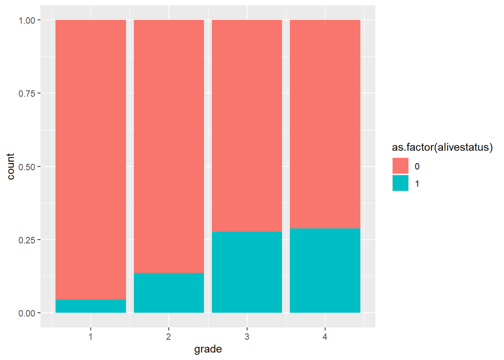

```r
library(ggplot2)
ggplot(data_10yr_filter) +
  geom_bar(mapping = aes(x=grade,
           fill=as.factor(alivestatus)),
           stat = "count", position="fill")
```

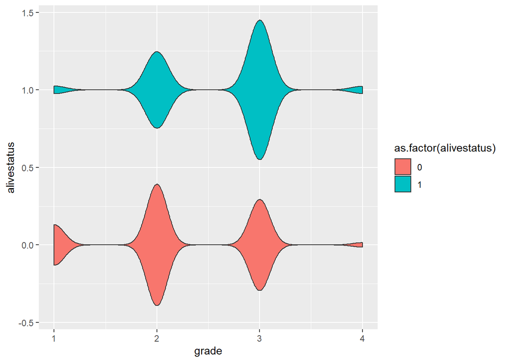

```r
ggplot(data_10yr_filter) +
  geom_violin(mapping = aes(x=grade,y=alivestatus,
           fill=as.factor(alivestatus)))
```

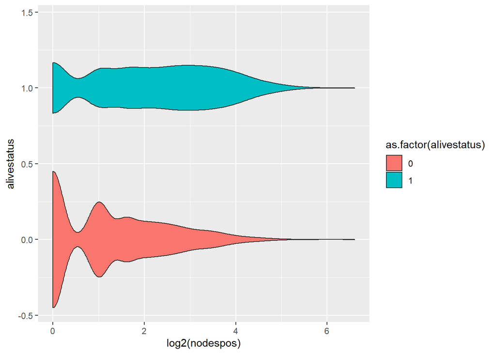

```r
ggplot(data_10yr_filter) +
  geom_violin(mapping = aes(x=log2(nodespos),y=alivestatus,
           fill=as.factor(alivestatus)))
```

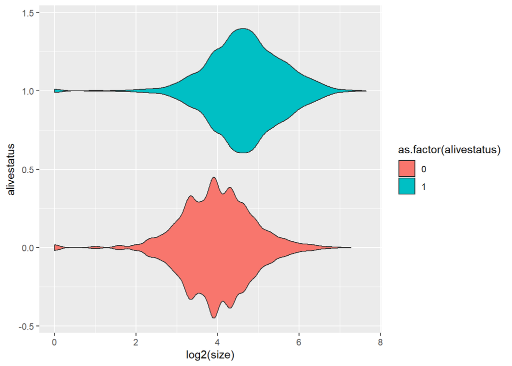

```r
ggplot(data_10yr_filter) +
  geom_violin(mapping = aes(x=log2(size),y=alivestatus,
                           fill=as.factor(alivestatus)))
```

## How do we know where to draw the line

We want to do a good job in predictive alive status but we know there is no one cutoff that will be always correct. So we need to minimize the error that we get. How do we do that? Check every value, one by one? That would take too long.

There are several method that are used to optimize the speed at which to approach the best solution. One takes a *learning rate* and multiples it with the magnitude of the error.

Basically if you know your cutoff is really wrong than you need to cutoff significantly.

Letâs try it using size as our predictor. Remember we are predicting the event death.

```r
#let's see what percent of our samples are actually dead
mean(data_10yr_filter$alivestatus)
```

```
## [1] 0.1836667
```

```r
size_cutoff=10

alive_pred = subset(data_10yr_filter, size<=size_cutoff)
dead_pred = subset(data_10yr_filter, size > size_cutoff)

#percent dead in our prediction
nrow(dead_pred)/nrow(data_10yr_filter)
```

```
## [1] 0.7731333
```

```r
# how many predictions were correct overall
correct_pred = sum(alive_pred$alivestatus == 0) + sum(dead_pred$alivestatus==1)

correct_pred/nrow(data_10yr_filter)
```

```
## [1] 0.3812
```

We should increase our cutoff, we are predicting too many to be dead

```r
size_cutoff=20

alive_pred = subset(data_10yr_filter, size<=size_cutoff)
dead_pred = subset(data_10yr_filter, size > size_cutoff)

#percent dead in our prediction
nrow(dead_pred)/nrow(data_10yr_filter)
```

```
## [1] 0.3538667
```

```r
correct_pred = sum(alive_pred$alivestatus == 0) + sum(dead_pred$alivestatus==1)

correct_pred/nrow(data_10yr_filter)
```

```
## [1] 0.6922
```

Much better, keep going the same direction but maybe slow down.

```r
size_cutoff=25

alive_pred = subset(data_10yr_filter, size<=size_cutoff)
dead_pred = subset(data_10yr_filter, size > size_cutoff)

#percent alive in our prediction
nrow(dead_pred)/nrow(data_10yr_filter)
```

```
## [1] 0.2267333
```

```r
correct_pred = sum(alive_pred$alivestatus == 0) + sum(dead_pred$alivestatus==1)

correct_pred/nrow(data_10yr_filter)
```

```
## [1] 0.758
```

Letâs write a loop to do this and then we can visualize the plot

```r
prediction_results = data.frame(cutoff=numeric(),
                                dead_pred = numeric(),
                                correct_pred=numeric())

for (i in 1:max(data_10yr_filter$size)) {

  alive_pred = subset(data_10yr_filter, size<=i)
  dead_pred = subset(data_10yr_filter, size > i)

  prediction_results[i,"cutoff"]=i
  #percent alive in our prediction
  prediction_results[i,"dead_pred"]=nrow(dead_pred)/nrow(data_10yr_filter)
  correct_pred = sum(alive_pred$alivestatus == 0) + sum(dead_pred$alivestatus==1)

  prediction_results[i,"correct_pred"] = correct_pred/nrow(data_10yr_filter)


}

head(prediction_results)
```

```
##   cutoff dead_pred correct_pred
## 1      1 0.9935333    0.1882667
## 2      2 0.9909333    0.1903333
## 3      3 0.9862000    0.1944000
## 4      4 0.9800000    0.1994000
## 5      5 0.9626000    0.2149333
## 6      6 0.9436667    0.2324000
```

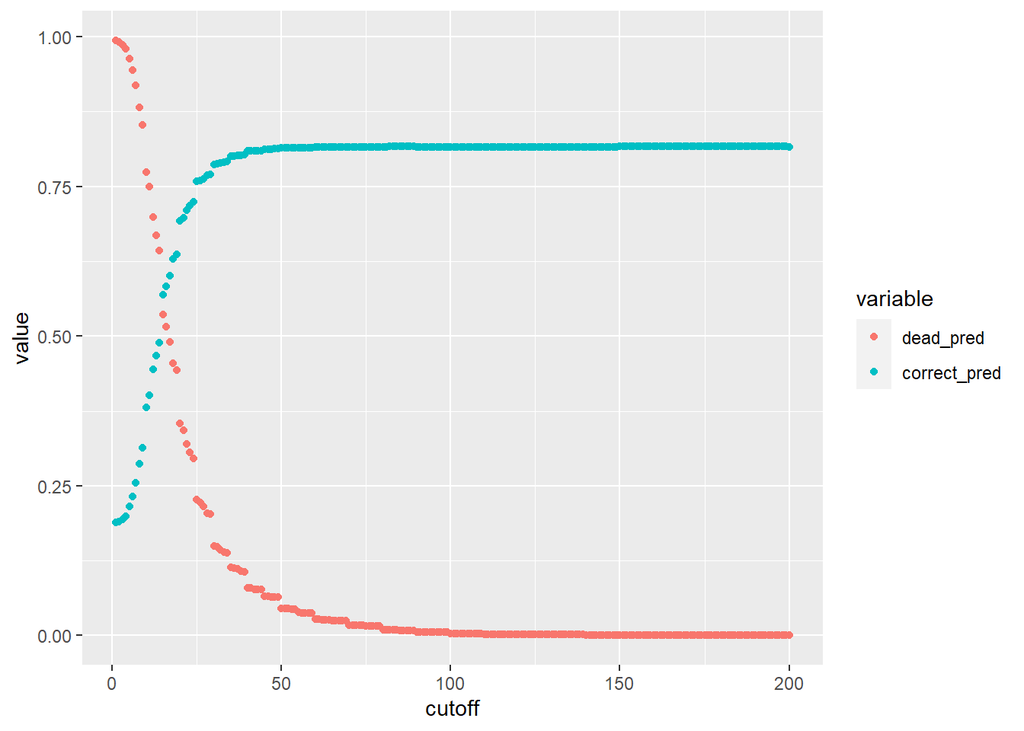

```r
library(reshape2)
prediction_melt = melt(prediction_results, id.vars = c("cutoff"))

ggplot(prediction_melt) +
  geom_point(mapping=aes(x=cutoff, y=value, col=variable))
```

```r
summary(prediction_results)
```

```
##      cutoff         dead_pred         correct_pred
##  Min.   :  1.00   Min.   :0.000000   Min.   :0.1883
##  1st Qu.: 50.75   1st Qu.:0.000200   1st Qu.:0.8145
##  Median :100.50   Median :0.003233   Median :0.8161
##  Mean   :100.50   Mean   :0.101065   Mean   :0.7696
##  3rd Qu.:150.25   3rd Qu.:0.045033   3rd Qu.:0.8164
##  Max.   :200.00   Max.   :0.993533   Max.   :0.8166
```

```r
bestres = which(prediction_results$correct_pred == max(prediction_results$correct_pred))
prediction_results[bestres,]
```

```
##    cutoff dead_pred correct_pred
## 88     88    0.0084       0.8166
## 89     89    0.0084       0.8166
```

## What are we not considering when we think of accuracy

In order to compare the predicted with actual results there are certain terminologies that are important to understand:

- TP: True positive: Predictions of TRUE event and it is actually TRUE
- TN: True negative: Prediction of FALSE event and it is actually FALSE.
- FP: False positive: Prediction of TRUE even, but it is actually FALSE.
- FN: False negative: Prediction of FALSE even and it is TRUE

These numbers in combination can provide useful statistics to judge the quality of the model.

- accuracy: total number of correct predictions divided by all possible predictions and events.
- recall: of all actual TRUE events, how many were predicted to be TRUE. Also known as **Sensitivity** and TPR (true positive rate)
- precision: of all predicted TRUE, how many were actually true
- TNR: True negative rate: Of all actual FALSE events, how many were predicted FALSE. Also known as **Specificity**

```r
prediction_results = data.frame(cutoff=numeric(),
                                recall = numeric(),
                                specificity=numeric(),
                                precision = numeric(),
                                correct_pred=numeric())

for (i in 1:max(data_10yr_filter$size)) {
  alive_total = subset(data_10yr_filter, alivestatus==0)
  dead_total = subset(data_10yr_filter, alivestatus==1)
  alive_pred = subset(data_10yr_filter, size<=i)
  dead_pred = subset(data_10yr_filter, size > i)
  correct_alive = sum(alive_pred$alivestatus == 0)
  correct_dead = sum(dead_pred$alivestatus==1)
  prediction_results[i,"cutoff"]=i
  #percent alive in our prediction
  prediction_results[i,"recall"]=correct_dead/nrow(dead_total)
  prediction_results[i,"precision"]=correct_dead/nrow(dead_pred)
  prediction_results[i,"specificity"]= correct_alive/nrow(alive_total)
  correct_pred = correct_alive + correct_dead

  prediction_results[i,"correct_pred"] = correct_pred/nrow(data_10yr_filter)


}

head(prediction_results)
```

```
##   cutoff    recall specificity precision correct_pred
## 1      1 0.9949183 0.006778277 0.1839227    0.1882667
## 2      2 0.9934664 0.009636586 0.1841362    0.1903333
## 3      3 0.9916515 0.015026541 0.1846819    0.1944000
## 4      4 0.9883848 0.021886484 0.1852381    0.1994000
## 5      5 0.9833031 0.042057983 0.1876169    0.2149333
## 6      6 0.9793103 0.064352797 0.1906040    0.2324000
```

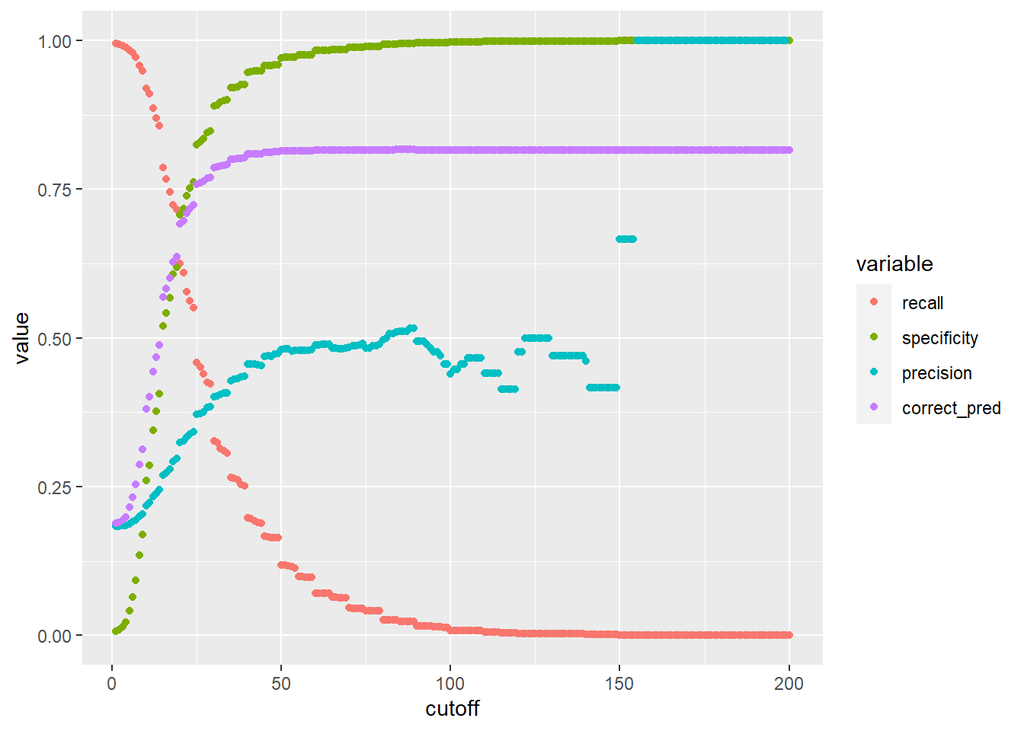

```r
prediction_melt = melt(prediction_results, id.vars = c("cutoff"))

ggplot(prediction_melt) +
  geom_point(mapping=aes(x=cutoff, y=value, col=variable))
```

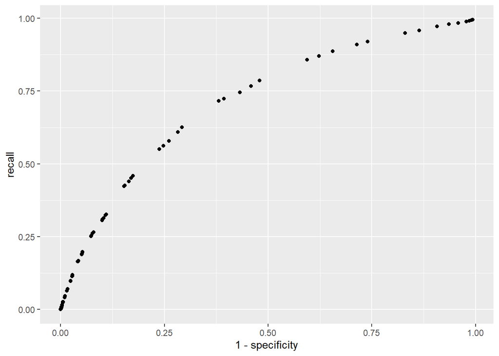

```r
ggplot(prediction_results) +
  geom_point(mapping=aes(x=1-specificity, y=recall))
```